# Gathering, Cleaning, and Analyzing WeRateDogs Twitter Archive

# Introduction

This dataset comes from an archive of tweets from the Twitter user @dog_rates, also known as WeRateDogs. This account rates people's dogs along with a humorous comment about the dog. The dog then gets a rating that almost always has a denominator of 10. The numerators on the other hand, almost always go beyond 10, [because they're good dogs Brent](https://knowyourmeme.com/memes/theyre-good-dogs-brent). The account has over 7 million followers as of 2018. In this notebook, I will wrangle, clean, and analyze the twitter archive and other supporting data.

### The Process

The data for this project requires gathering from a few different sources. The twitter archive, `df_twitter`, comes from a file given to Udacity by WeRateDogs. The other file, `image_predictions` comes from Udacity's servers and will be downloaded by utilizing the `requests` library. All other data will be gathered by accessing the Twitter API and extracting the JSON of each tweet. I will then use the extracted JSON to add extra data to `df_twitter`. I also use the `BeautifulSoup` library to extract users that were tagged in the photos of the tweet. Once I gather all the data I need, I will clean and visualize it.

### Twitter Archive

The archive was downloaded using [this link](https://d17h27t6h515a5.cloudfront.net/topher/2017/August/59a4e958_twitter-archive-enhanced/twitter-archive-enhanced.csv). In the table there are a total of 17 columns. Most of these columns are described on the [twitter developer web page](https://developer.twitter.com/en/docs/tweets/data-dictionary/overview/tweet-object.html) on tweet objects.

### Image Predictions

This file was downloaded using [this link](https://d17h27t6h515a5.cloudfront.net/topher/2017/August/599fd2ad_image-predictions/image-predictions.tsv) and the `requests` library to save the file for analysis. The column descriptions are as follows:

- tweet_id is the last part of the tweet URL after "status/" → https://twitter.com/dog_rates/status/889531135344209921
- p1 is the algorithm's #1 prediction for the image in the tweet → golden retriever
- p1_conf is how confident the algorithm is in its #1 prediction → 95%
- p1_dog is whether or not the #1 prediction is a breed of dog → TRUE
- p2 is the algorithm's second most likely prediction → Labrador retriever
- p2_conf is how confident the algorithm is in its #2 prediction → 1%
- p2_dog is whether or not the #2 prediction is a breed of dog → TRUE
- etc.

# Gather

```python
import requests
import pandas as pd
import tweepy
import time
import json
from bs4 import BeautifulSoup
import re
from collections import defaultdict
import os
```

```python
# get image-predictions.tsv with requests library
r = requests.get('https://d17h27t6h515a5.cloudfront.net/topher/2017/August/599fd2ad_image-predictions/image-predictions.tsv')
```

```python
# save file
with open('data/image-predictions.tsv', 'wb') as file:
    file.write(r.content)
```

Below, I wrote a script that loops through the `tweet_id` column and uses each ID to access the tweet JSON. I then store all of the json in a list, which then gets outputed to a text file at the end of the script. While the loop is running, it catches errors and stores the ID's in a list called `tweet_errors`. Also, the script will print out any ID's that it has errors with. It's nice to be able to track what your script is doing when it runs for such a long time. When you access the twitter API too much, you reach your rate limit. Once this happens, the script gets "put to sleep" for 15 to 30 minutes. This was one of the biggest challenges of this project. Since it takes roughly an hour for this script to run, it needed to be tested on a much smaller scale so there are zero errors when used on the dataset.

While writing this script, I stumbled upon a very useful technique for gathering data. This method comes from the `collections` library. I imported a method called `defaultdict`. Essentially it makes a basic python dictionary, but with something a little extra. If the key in the dictionary is not present, it will put a new key with it's value in the dictionary. Once you need to add another value to the same key, it will add the value to the same key as a list. So no matter what, you will create a dictionary that you can later turn into a dataframe with a few lines of code.

Once the JSON is dumped and the dictionary is turned into a dataframe, the dataframe is then turned into a csv file for later cleaning and analysis.

Next, I will use the twitter API to access the JSON of each tweet. I will use each ID from the `tweet_id` column in `df_twitter`, save the JSON to a text file, then use that text file to find more data on each tweet.

```python
# oauth authentication
auth = tweepy.OAuthHandler(consumer_key, consumer_secret, callback_url)
```

```python
try:
    redirect_url = auth.get_authorization_url()
except tweepy.TweepError:
    print('Error! Failed to get request token.')
```

```python
# access the api using the tweepy library
api = tweepy.API(auth,
                 parser = tweepy.parsers.JSONParser(),
                 wait_on_rate_limit = True,
                 wait_on_rate_limit_notify = True)
```

```python
# start timer
start_time = time.time()
# list of tweet json
tweet_json = []
# dictionary of extracted tweet data
tweet_dict = defaultdict(list)
# errors (if any) of tweet extraction
tweet_errors = []

for tweet_id in df_twitter.tweet_id:
    try:
        # get tweet
        tweet = api.get_status(tweet_id, tweet_mode = 'extended')
        # append json to tweet_json list
        tweet_json.append(tweet)
        # extract tweet data
        tweet_dict['retweet_count'].append(tweet['retweet_count'])
        tweet_dict['favorite_count'].append(tweet['favorite_count'])
        tweet_dict['tweet_id'].append(tweet['id'])
    except:
        # if tweet is not extracted, append id to tweet_errors
        tweet_errors.append(tweet_id)
        # print id with error
        print('error in extracting' + ' ' + str(tweet_id))
# dump json into txt file
with open('json/tweet_json.txt', 'w', encoding = 'utf8') as tweettxtfile:
    json.dump(tweet_json, tweettxtfile, sort_keys = True, indent = 4, ensure_ascii = False)
# dict to dataframe
df_twitter_extract = pd.DataFrame.from_dict(tweet_dict)
# dataframe to csv
df_twitter_extract.to_csv('data/df_twitter_extract.csv', encoding='utf-8')
print('Script took %s seconds to run' % (time.time() - start_time))
error_length = len(tweet_errors)
print('There were %s tweet errors when the script was ran' % error_length)
```

```
error in extracting 888202515573088257
error in extracting 873697596434513921
error in extracting 869988702071779329
error in extracting 866816280283807744
error in extracting 861769973181624320
error in extracting 845459076796616705
error in extracting 842892208864923648
error in extracting 837012587749474308
error in extracting 827228250799742977
error in extracting 802247111496568832
error in extracting 775096608509886464
error in extracting 771004394259247104
error in extracting 770743923962707968
```

```
Rate limit reached. Sleeping for: 325
```

```
error in extracting 754011816964026368
```

```
Rate limit reached. Sleeping for: 680
```

```
Script took 1618.222422361374 seconds to run
There were 14 tweet errors when the script was ran
```

Surprisingly, there were only 14 errors when the script was ran. After checking the `tweet_json.txt`, there are a total of 461,441 lines of JSON. For the file I used the `sort_keys`, `indent`, and `ensure_ascii` to make a clean and readable json file. This helped later on when I needed to view a twitter object in the JSON file to figure out what code I needed to access certain elements.

Next, I extracted the `retweeted` status of each tweet and added it to the `df_twitter` table.

```python
retweet_status_dict = defaultdict(list)
json_file = 'json/tweet_json.txt'
with open(json_file, encoding = 'utf-8') as f:
    data = json.load(f)
    for element in data:
        retweet_status_dict['retweeted'].append(element['retweeted'])
        retweet_status_dict['tweet_id'].append(element['id'])
    print('done!')
df_retweet_status = pd.DataFrame.from_dict(retweet_status_dict)
```

```
done!
```

For the next part, I wanted to add some extra data to the project. I wanted to extract the JSON of the user's who were getting tagged in certain tweets on WeRateDogs. Using the ID's from `twitter_df`, I accessed the url's of the tweets with the `BeautifulSoup` library. Then, I saved the html of each url in a folder for later use. I named each file by splitting the string of the url and adding the ID to the file name.

```python
start_time = time.time()

html_tweet_dict = defaultdict(list)

html_tweet_errors = []
for tweet_id in df_twitter.tweet_id:
    try:
        url = api.get_status(tweet_id)['entities']['urls'][0]['expanded_url']
        r = requests.get(url)
        html_tweet_dict['link'].append(url)
        html_tweet_dict['tweet_id'].append(tweet_id)
        # access html with BeautifulSoup
        soup = BeautifulSoup(r.text, 'html.parser').prettify()
        # save html of tweet to tweet_html folder
        with open('tweet_html/html_' + url.split('/')[-1] + '.html', 'w', encoding = 'utf-8') as file:
            file.write(str(soup))
    except:
        html_tweet_errors.append(tweet_id)
        print('error in obtaining url from tweet ID %s' % tweet_id)

# turn dict into dataframe
df_html_extract = pd.DataFrame.from_dict(html_tweet_dict)
# dataframe to csv
df_html_extract.to_csv('data/df_html_extract.csv', encoding='utf-8')

print('Script took %s seconds to run' % (time.time() - start_time))
html_error_length = len(html_tweet_errors)
print('There were %s user tweet errors when the script was ran' % html_error_length)
```

```python
len(html_tweet_errors)
```

```
1973
```

After running this script, there were a total of 1973 errors. The cause of the errors was the `url` variable in the loop. Due to some tweets being a bit old, the JSON of those tweets were different than others. So to narrow down the number of errors. I searched for another way to grab the url from the JSON and ran the script again.

```python
start_time = time.time()

html_tweet_errors_2 = []

# loop through html_tweet_errors
for tweet_id in html_tweet_errors:
    try:
        # changed strings to access correct link
        url = api.get_status(tweet_id)['entities']['media'][0]['expanded_url']
        r = requests.get(url)
        html_tweet_dict['link'].append(url)
        html_tweet_dict['tweet_id'].append(tweet_id)
        soup = BeautifulSoup(r.text, 'html.parser').prettify()
        # save html of tweet to tweet_html folder (changed index to -3)
        with open('tweet_html/html_' + url.split('/')[-3] + '.html', 'w', encoding = 'utf-8') as file:
            file.write(str(soup))
    except:
        html_tweet_errors_2.append(tweet_id)
        print('error in obtaining url from tweet ID %s' % tweet_id)

df_html_extract_2 = pd.DataFrame.from_dict(html_tweet_dict)
# dataframe to csv
df_html_extract_2.to_csv('data/df_html_extract_.csv', encoding='utf-8')

print('Script took %s seconds to run' % (time.time() - start_time))
html_error_length_2 = len(html_tweet_errors_2)
print('There were %s user tweet errors when the script was ran' % html_error_length_2)
```

```python
len(html_tweet_errors_2)
```

```
153
```

I narrowed it down to 153 errors. AFter some digging, most of the other 153 ID's url's didn't exist on twitter anymore, so I decided to move on.

With those two scripts ran, I now have the HTML for most of the tweets. I also have a CSV file called `df_html_extract` that has the ID and the url of that ID. This will be used later to add missing data to the `df_twitter` dataframe.

Next, I will use the HTML files extracted earlier and find the user ID of the profile tagged in the original tweet. After inspecting the link of the tagged user on twitter, I discovered that there was a `div` with a class called `media-tagging-block` that had a number in `data-user-id`. With this ID number, we can use `api.get_user` to extract the json just as we did with the original tweets.

So for the script I wrote below, it will loop through the html files, find the user ID number, extract the JSON of the user, and collect data from it. After all of the data is collected it puts it in a csv file called `df_user_extract`.

```python
# list of user tweet json
user_tweet_json = []
# tweet data of users tagged in original tweet
user_tweet_dict = defaultdict(list)
# list of errors
user_tweet_error = []
folder = 'tweet_html'
for tweet_html in os.listdir(folder):
    try:
        with open(os.path.join(folder, tweet_html), encoding = 'utf-8') as file:
            soup = BeautifulSoup(file, 'html.parser')
            # find user ID of profile tagged in original tweet
            user_id = soup.find('div', 'media-tagging-block')('a')[0].get('data-user-id')
            # get profile JSON using user ID
            user_json = api.get_user(user_id)
            # put json in user_tweet_json
            user_tweet_json.append(user_json)
            # extract user profile data
            user_tweet_dict['created_at'].append(user_json['created_at'])
            user_tweet_dict['friends_count'].append(user_json['friends_count'])
            user_tweet_dict['user_id'].append(user_json['id_str'])
            user_tweet_dict['language'].append(user_json['lang'])
            user_tweet_dict['location'].append(user_json['location'])
            user_tweet_dict['display_name'].append(user_json['name'])
            user_tweet_dict['account_name'].append(user_json['screen_name'])
    except:
        user_tweet_error.append(file)
        print('error in obtaining tagged user ID data from %s' % file)
```

```python
with open('json/user_tweet_json.txt', 'w', encoding = 'utf-8') as usertxtfile:
    json.dump(user_tweet_json, usertxtfile, sort_keys = True, indent = 4, ensure_ascii = False)
df_user_extract = pd.DataFrame.from_dict(user_tweet_dict)
# dataframe to csv
df_user_extract.to_csv('data/df_user_extract.csv', encoding='utf-8')
```

```python
len(user_tweet_error)
```

```
1412
```

With this script I was able to extract user data for 718 individuals. There were 1412 errors mostly because not all tweets had a tagged user in it. The data I was able to collect included the date in which the user joined twitter, friends count, user ID, language spoken, location of user, display name, and account name.

In summary, I collected the twitter archive of WeRateDogs, the HTMl of each tweet link, tagged user data, image predictions from Udacity's servers, and JSON for tagged users and for each tweet in the archive. The next step will be to clean and organize the data, so we have good quality and tidiness for analyzation.

# Assess

```python
# make a copy of df_twitter to alter it later
df_twitter = pd.read_csv('data/twitter-archive-enhanced.csv')
df_twitter_copy = df_twitter.copy()
df_twitter_copy.head()
```

|  | tweet_id | in_reply_to_status_id | in_reply_to_user_id | timestamp | source | text | retweeted_status_id | retweeted_status_user_id | retweeted_status_timestamp | expanded_urls | rating_numerator | rating_denominator | name | doggo | floofer | pupper | puppo |
| --- | --- | --- | --- | --- | --- | --- | --- | --- | --- | --- | --- | --- | --- | --- | --- | --- | --- |
| 0 | 892420643555336193 | NaN | NaN | 2017-08-01 16:23:56 +0000 | <a href="http://twitter.com/download/iphone" r... | This is Phineas. He's a mystical boy. Only eve... | NaN | NaN | NaN | https://twitter.com/dog_rates/status/892420643... | 13 | 10 | Phineas | None | None | None | None |
| 1 | 892177421306343426 | NaN | NaN | 2017-08-01 00:17:27 +0000 | <a href="http://twitter.com/download/iphone" r... | This is Tilly. She's just checking pup on you.... | NaN | NaN | NaN | https://twitter.com/dog_rates/status/892177421... | 13 | 10 | Tilly | None | None | None | None |
| 2 | 891815181378084864 | NaN | NaN | 2017-07-31 00:18:03 +0000 | <a href="http://twitter.com/download/iphone" r... | This is Archie. He is a rare Norwegian Pouncin... | NaN | NaN | NaN | https://twitter.com/dog_rates/status/891815181... | 12 | 10 | Archie | None | None | None | None |
| 3 | 891689557279858688 | NaN | NaN | 2017-07-30 15:58:51 +0000 | <a href="http://twitter.com/download/iphone" r... | This is Darla. She commenced a snooze mid meal... | NaN | NaN | NaN | https://twitter.com/dog_rates/status/891689557... | 13 | 10 | Darla | None | None | None | None |
| 4 | 891327558926688256 | NaN | NaN | 2017-07-29 16:00:24 +0000 | <a href="http://twitter.com/download/iphone" r... | This is Franklin. He would like you to stop ca... | NaN | NaN | NaN | https://twitter.com/dog_rates/status/891327558... | 12 | 10 | Franklin | None | None | None | None |

```python
df_twitter_copy.info()
```

```
<class 'pandas.core.frame.DataFrame'>
RangeIndex: 2356 entries, 0 to 2355
Data columns (total 17 columns):
tweet_id                      2356 non-null int64
in_reply_to_status_id         78 non-null float64
in_reply_to_user_id           78 non-null float64
timestamp                     2356 non-null object
source                        2356 non-null object
text                          2356 non-null object
retweeted_status_id           181 non-null float64
retweeted_status_user_id      181 non-null float64
retweeted_status_timestamp    181 non-null object
expanded_urls                 2297 non-null object
rating_numerator              2356 non-null int64
rating_denominator            2356 non-null int64
name                          2356 non-null object
doggo                         2356 non-null object
floofer                       2356 non-null object
pupper                        2356 non-null object
puppo                         2356 non-null object
dtypes: float64(4), int64(3), object(10)
memory usage: 313.0+ KB
```

- Missing values (NaN)
- tweet_id is an int64 column, not str
- source column needs re-formatting, should not be html elements
- doggo, floofer, pupper, and puppo should be one column
- timestamp should be datetime

```python
image_predictions = pd.read_csv('data/image-predictions.tsv', sep = '\t')
image_predictions_copy = image_predictions.copy()
image_predictions_copy.head()
```

|  | tweet_id | jpg_url | img_num | p1 | p1_conf | p1_dog | p2 | p2_conf | p2_dog | p3 | p3_conf | p3_dog |
| --- | --- | --- | --- | --- | --- | --- | --- | --- | --- | --- | --- | --- |
| 0 | 666020888022790149 | https://pbs.twimg.com/media/CT4udn0WwAA0aMy.jpg | 1 | Welsh_springer_spaniel | 0.465074 | True | collie | 0.156665 | True | Shetland_sheepdog | 0.061428 | True |
| 1 | 666029285002620928 | https://pbs.twimg.com/media/CT42GRgUYAA5iDo.jpg | 1 | redbone | 0.506826 | True | miniature_pinscher | 0.074192 | True | Rhodesian_ridgeback | 0.072010 | True |
| 2 | 666033412701032449 | https://pbs.twimg.com/media/CT4521TWwAEvMyu.jpg | 1 | German_shepherd | 0.596461 | True | malinois | 0.138584 | True | bloodhound | 0.116197 | True |
| 3 | 666044226329800704 | https://pbs.twimg.com/media/CT5Dr8HUEAA-lEu.jpg | 1 | Rhodesian_ridgeback | 0.408143 | True | redbone | 0.360687 | True | miniature_pinscher | 0.222752 | True |
| 4 | 666049248165822465 | https://pbs.twimg.com/media/CT5IQmsXIAAKY4A.jpg | 1 | miniature_pinscher | 0.560311 | True | Rottweiler | 0.243682 | True | Doberman | 0.154629 | True |

```python
image_predictions_copy.info()
```

```
<class 'pandas.core.frame.DataFrame'>
RangeIndex: 2075 entries, 0 to 2074
Data columns (total 12 columns):
tweet_id    2075 non-null int64
jpg_url     2075 non-null object
img_num     2075 non-null int64
p1          2075 non-null object
p1_conf     2075 non-null float64
p1_dog      2075 non-null bool
p2          2075 non-null object
p2_conf     2075 non-null float64
p2_dog      2075 non-null bool
p3          2075 non-null object
p3_conf     2075 non-null float64
p3_dog      2075 non-null bool
dtypes: bool(3), float64(3), int64(2), object(4)
memory usage: 152.1+ KB
```

- tweet_id needs to be string

The `image_predictions` file is pretty tidy. From only looking at the first five rows, I can already see that I will probably only need the `tweet_id`, `jpg_url`, `p1`, and `p1_conf` columns of the rows that contain `True` in `p1_dog`. The other columns have a very low confidence percentage and will not be necessary to add to the data. Next lets look at the twitter archive.

```python
df_html_extract = pd.read_csv('data/df_html_extract.csv')
df_html_extract_copy = df_html_extract.copy()
df_html_extract_copy.head()
```

|  | Unnamed: 0 | link | tweet_id |
| --- | --- | --- | --- |
| 0 | 0 | https://twitter.com/i/web/status/8921774213063... | 892177421306343426 |
| 1 | 1 | https://twitter.com/i/web/status/8918151813780... | 891815181378084864 |
| 2 | 2 | https://twitter.com/i/web/status/8913275589266... | 891327558926688256 |
| 3 | 3 | https://twitter.com/i/web/status/8910879508758... | 891087950875897856 |
| 4 | 4 | https://twitter.com/i/web/status/8909719131739... | 890971913173991426 |

```python
df_html_extract.info()
```

```
<class 'pandas.core.frame.DataFrame'>
RangeIndex: 2207 entries, 0 to 2206
Data columns (total 3 columns):
Unnamed: 0    2207 non-null int64
link          2207 non-null object
tweet_id      2207 non-null int64
dtypes: int64(2), object(1)
memory usage: 51.8+ KB
```

- remove unnamed column
- tweet_id needs to be string

```python
# extra data extracted for twitter archive
df_twitter_extract = pd.read_csv('data/df_twitter_extract.csv')
df_twitter_extract_copy = df_twitter_extract.copy()
df_twitter_extract_copy.head()
```

|  | Unnamed: 0 | favorite_count | retweet_count | tweet_id |
| --- | --- | --- | --- | --- |
| 0 | 0 | 38489 | 8472 | 892420643555336193 |
| 1 | 1 | 32964 | 6237 | 892177421306343426 |
| 2 | 2 | 24829 | 4133 | 891815181378084864 |
| 3 | 3 | 41857 | 8597 | 891689557279858688 |
| 4 | 4 | 40017 | 9327 | 891327558926688256 |

```python
df_twitter_extract_copy.info()
```

```
<class 'pandas.core.frame.DataFrame'>
RangeIndex: 2342 entries, 0 to 2341
Data columns (total 4 columns):
Unnamed: 0        2342 non-null int64
favorite_count    2342 non-null int64
retweet_count     2342 non-null int64
tweet_id          2342 non-null int64
dtypes: int64(4)
memory usage: 73.3 KB
```

- remove unnamed column
- change tweet_id to string

```python
df_user_extract = pd.read_csv('data/df_user_extract.csv')
df_user_extract_copy = df_user_extract.copy()
df_user_extract_copy.head()
```

|  | Unnamed: 0 | account_name | created_at | display_name | friends_count | language | location | user_id |
| --- | --- | --- | --- | --- | --- | --- | --- | --- |
| 0 | 0 | dog_rates | Sun Nov 15 21:41:29 +0000 2015 | WeRateDogs™ | 10 | en | ⇩ merch ⇩ DM YOUR DOGS | 4196983835 |
| 1 | 1 | tta_kay | Sat Jul 05 17:06:22 +0000 2014 | kay | 479 | en | NaN | 2676442024 |
| 2 | 2 | Adeline_Garrett | Fri Apr 26 16:34:47 +0000 2013 | outofline carrot 🦊 | 415 | en | 912•LDN | 1382344291 |
| 3 | 3 | gwatsky | Sun Jan 10 03:38:19 +0000 2010 | W▵TSKY | 865 | en | yeah | 103467620 |
| 4 | 4 | SmilingYoshi | Sun Jun 12 20:38:49 +0000 2011 | SmilingYoshi | 1412 | en | Here. | 316025613 |

```python
df_user_extract_copy.info()
```

```
<class 'pandas.core.frame.DataFrame'>
RangeIndex: 718 entries, 0 to 717
Data columns (total 8 columns):
Unnamed: 0       718 non-null int64
account_name     718 non-null object
created_at       718 non-null object
display_name     718 non-null object
friends_count    718 non-null int64
language         718 non-null object
location         457 non-null object
user_id          718 non-null int64
dtypes: int64(3), object(5)
memory usage: 45.0+ KB
```

- NaN values
- remove unnamed column
- created_at should be datetime
- change user_id to string

# Clean

### Define

- remove all rows that have values in `retweeted_status_id`, `retweeted_status_user_id`, and `retweeted_status_timestamp`
- Change `tweet_id` column to a `string`
- Change `timestamp` to `datetime`
- Extract the text in each row for the `source column` with beautiful soup
- Extract numerator and denominator from text column to clean up current columns
- Create a column that divides the numerator to the denominator to have a common rating system
- Fix any outliers in the `name` column, for example, "a" as a name
- doggo, floofer, pupper, puppo columns in twitter_archive_enhanced.csv should be combined into a single column as this is one variable that identify stage of dog.
- fix three missing urls in `expanded_urls` column
- All data pertaining to the twitter archive information needs to be on one table.
- combine `df_twitter_extract` with `df_twitter`
- combine `image_predictions` with `df_twitter`

### Code

The only data frame that I will be changing and adding data too is `df_twitter`. Mainly because all of my other tables (except `df_user_extract`) have the `tweet_id`'s in each. One method you will see throughout this cleaning process is `map`. Conveniently, I can use the tweet ID's from my extracted data and map it to the twitter archive data. That way, we have the data next to the associated tweet ID.

First I will start off by removing rows we don't need. Particularly the tweets that are retweets.

```python
# filter dataframe by rows that don't have values in retweeted_status_id
df_twitter_copy = df_twitter_copy[df_twitter_copy['retweeted_status_id'].isnull()]
```

Now that we've filtered out the retweets in the data, we can remove the three "retweet" columns

```python
# drop retweet columns
df_twitter_copy = df_twitter_copy.drop(['retweeted_status_id', 'retweeted_status_user_id', 'retweeted_status_timestamp'], axis = 1)
```

We can also do the same thing with the "reply" columns, as they are not original tweets with image ratings.

```python
# filter dataframe by rows that don't have values in in_reply_to_status_id
df_twitter_copy = df_twitter_copy[df_twitter_copy['in_reply_to_status_id'].isnull()]
```

```python
# drop reply columns
df_twitter_copy = df_twitter_copy.drop(['in_reply_to_status_id', 'in_reply_to_user_id'], axis = 1)
```

In the next steps, I will turn the `tweet_id` column in to a string type, and `timestamp` into DateTime type. Since the ID numbers do not need to be calculated in any mathematical way and shouldn't be changed, they should be strings. The DateTime type for the `timestamp` column will be usefull for visualization when I need to put elements in order by time.

```python
# turn tweet_id into string type
df_twitter_copy['tweet_id'] = df_twitter_copy['tweet_id'].astype('str')
```

```python
# turn timestamp into DateTime
df_twitter_copy['timestamp'] = pd.to_datetime(df_twitter_copy['timestamp'])
```

For this next section I used BeautifulSoup to extract the content in each html tag for the `source` column. BeauifulSoup was the easiest method to use for parsing the html string. Once I was able to extract the content of each tag, I then used the `replace` method to change the source types into simple strings such as iphone, vine, web, and tweetdeck.

```python
# function for accessing tag content
def source_text(html):
    source = BeautifulSoup(html, 'lxml')
    return source.a.string

# change each cell to tag content with lambda function
df_twitter_copy['source'] = df_twitter_copy.apply(lambda row: source_text(row['source']), axis = 1)
```

```python
# dictionary of string replacements
replacements = {
    'Twitter for iPhone': 'iphone',
    'Vine - Make a Scene': 'vine',
    'Twitter Web Client': 'web',
    'TweetDeck': 'tweetdeck'
}

# apply replacements
df_twitter_copy['source'] = df_twitter_copy['source'].replace(replacements)
```

Next, I extracted the ratings from the text in the twitter archive, split up the ratings, and added the new columns to the archive

```python
# extract the ratings using regex
extract = df_twitter_copy.text.str.extract('(\d.?\.?.?.?\/..\d?)', expand = True)
# split the ratings at the character "/"
extract = extract[0].str.split('/')
# turn it into a dataframe
extract = pd.DataFrame(extract)
# name the column
extract.columns = ['rating']
```

```python
# split the ratings into two columns
extract[['rating_numerator', 'rating_denominator']] = pd.DataFrame(extract.rating.values.tolist(), index = extract.index)
```

```python
# drop original ratings columns
df_twitter_copy = df_twitter_copy.drop(['rating_numerator', 'rating_denominator'], axis = 1)
```

```python
# add new columns to archive
df_twitter_copy['rating_numerator'] = extract['rating_numerator']
df_twitter_copy['rating_denominator'] = extract['rating_denominator']
```

Even though this is the Code section, I feel this needed to be addressed here. After doing a `value_counts()` call on the `rating_numerator` column, I noticed there was exactly one string that didn't look like a number. I identify it below

```python
df_twitter_copy[df_twitter_copy.rating_numerator == '3 1']
```

|  | tweet_id | timestamp | source | text | expanded_urls | name | doggo | floofer | pupper | puppo | rating_numerator | rating_denominator |
| --- | --- | --- | --- | --- | --- | --- | --- | --- | --- | --- | --- | --- |
| 2335 | 666287406224695296 | 2015-11-16 16:11:11 | iphone | This is an Albanian 3 1/2 legged Episcopalian... | https://twitter.com/dog_rates/status/666287406... | an | None | None | None | None | 3 1 | 2 |

Fixing this would require a simple `.at[]` function

```python
df_twitter_copy.at[2335, 'rating_numerator'] = '9'
df_twitter_copy.at[2335, 'rating_denominator'] = '10'
```

```python
# change rating columns to floats
df_twitter_copy['rating_numerator'] = df_twitter_copy['rating_numerator'].astype(float)
df_twitter_copy['rating_denominator'] = df_twitter_copy['rating_denominator'].astype(float)
```

Since the scores in this data vary in scale (14/10 , 150/164, for example) the best way to have a consistent score in the entire data set is to divide the numerator by the denominator. This will allow us to easily make visualizations that show us average score, scores over time, highest score, ect.

```python
# divide numerator column by denominator column
df_twitter_copy['score_rating'] = df_twitter_copy.rating_numerator / df_twitter_copy.rating_denominator
```

Focusing on the names now, we can use `str.contains()` with regular expressions to find all of the strings in the column that begin with a lower case letter. This returns a series that we can then turn into a list. With this list of strings, we can filter the dataframe to turn these strings into "None".

```python
# list of strings that begin with a lower case in the name column
no_name_list = df_twitter_copy[df_twitter_copy.name.str.contains('(^[a-z])')].name.tolist()
```

```python
# any string that is also in the list gets turned into "None"
df_twitter_copy.ix[df_twitter_copy.name.isin(no_name_list), 'name'] = 'None'
```

```python
# name of columns to iterate over
cols = ['doggo', 'floofer', 'pupper', 'puppo']

# make new none column
df_twitter_copy['dog_label'] = 'None'

# loop through columns, if all are none move on,
# if not, set column name as label for dog_label
for i in df_twitter_copy.index:
    for col in cols:
        if df_twitter_copy.at[i, col] == 'None':
            continue
        else:
            df_twitter_copy.at[i, 'dog_label'] = col
```

```python
# drop original label columns
df_twitter_copy = df_twitter_copy.drop(['doggo', 'floofer', 'pupper', 'puppo'], axis = 1)
```

Since there are only three missing values in `expanded_urls`, we can decide what to do with them individually. Lets look at the text of each of them.

```python
df_twitter_copy[df_twitter_copy.expanded_urls.isnull()]
```

|  | tweet_id | timestamp | source | text | expanded_urls | name | rating_numerator | rating_denominator | score_rating | dog_label |
| --- | --- | --- | --- | --- | --- | --- | --- | --- | --- | --- |
| 375 | 828361771580813312 | 2017-02-05 21:56:51 | web | Beebop and Doobert should start a band 12/10 w... | NaN | None | 12.0 | 10.0 | 1.2 | None |
| 707 | 785515384317313025 | 2016-10-10 16:20:36 | iphone | Today, 10/10, should be National Dog Rates Day | NaN | None | 10.0 | 10.0 | 1.0 | None |
| 1445 | 696518437233913856 | 2016-02-08 02:18:30 | iphone | Oh my god 10/10 for every little hot dog pupper | NaN | None | 10.0 | 10.0 | 1.0 | pupper |

```python
df_twitter_copy.loc[375].text
```

```
'Beebop and Doobert should start a band 12/10 would listen'
```

```python
df_twitter_copy.loc[707].text
```

```
'Today, 10/10, should be National Dog Rates Day'
```

```python
df_twitter_copy.loc[1445].text
```

```
'Oh my god 10/10 for every little hot dog pupper'
```

Even though these are original tweets of WeRateDogs, they are not ratings of dogs with pictures, they should be removed from the data frame.

```python
df_twitter_copy = df_twitter_copy[df_twitter_copy.expanded_urls.notnull()]
```

Next I will focus on the `df_twitter_extract` table. I'll clean it, then join it with the twitter archive.

```python
# change tweet_id to string
df_twitter_extract_copy['tweet_id'] = df_twitter_extract['tweet_id'].astype(str)
```

```python
# drop unnamed column
df_twitter_extract_copy = df_twitter_extract_copy.drop('Unnamed: 0', axis = 1)
```

```python
# map df_twitter_extract to df_twitter
df_twitter_copy['retweet_count'] = df_twitter_copy['tweet_id'].map(df_twitter_extract_copy.set_index('tweet_id')['retweet_count'])
df_twitter_copy['favorite_count'] = df_twitter_copy['tweet_id'].map(df_twitter_extract_copy.set_index('tweet_id')['favorite_count'])
```

```python
# one row NaN for retweet and favorite count
df_twitter_copy[df_twitter_copy.retweet_count.isnull()]
```

|  | tweet_id | timestamp | source | text | expanded_urls | name | rating_numerator | rating_denominator | score_rating | dog_label | retweet_count | favorite_count |
| --- | --- | --- | --- | --- | --- | --- | --- | --- | --- | --- | --- | --- |
| 932 | 754011816964026368 | 2016-07-15 17:56:40 | iphone | This is Charlie. He pouts until he gets to go ... | https://twitter.com/dog_rates/status/754011816... | Charlie | 12.0 | 10.0 | 1.2 | None | NaN | NaN |

```python
# tweet does not exist anymore, remove it
df_twitter_copy = df_twitter_copy[df_twitter_copy.retweet_count.notnull()]
```

In the next steps, I will focus on joining the `image_predictions` data with `df_twitter`. I will narrow the image predictions table down to only rows where `p1_dog` are `True`. We only want strings in the column that are actual dogs that exist. Along with the name of the breed, I'll also include the JPEG file of the dog, and the confidence level in which the algorithm calculated. Since the image predictions table get's narrowed down to about 500 less datapoints then the twitter archive, I'll have to fill in the missing data with either a string "None", or a zero for integer columns.

```python
# filter data where p1_dog is True
image_predictions_copy = image_predictions_copy[image_predictions_copy.p1_dog == True]
```

```python
image_predictions_copy[image_predictions_copy.p1_dog == True]
```

[output not shown]

```python
# tweet_id to string type
image_predictions_copy['tweet_id'] = image_predictions_copy['tweet_id'].astype(str)
```

```python
# map data to the twitter archive
df_twitter_copy['jpg_url'] = df_twitter_copy['tweet_id'].map(image_predictions_copy.set_index('tweet_id')['jpg_url'])
df_twitter_copy['p1'] = df_twitter_copy['tweet_id'].map(image_predictions_copy.set_index('tweet_id')['p1'])
df_twitter_copy['p1_conf'] = df_twitter_copy['tweet_id'].map(image_predictions_copy.set_index('tweet_id')['p1_conf'])
```

```python
# fill in NaN values
df_twitter_copy[['jpg_url', 'p1']] = df_twitter_copy[['jpg_url', 'p1']].fillna('None')
df_twitter_copy['p1_conf'] = df_twitter_copy['p1_conf'].fillna(0)
```

Lastly, I will do some quick cleaning on the `df_user_extract` dataframe.

```python
df_user_extract_copy['user_id'] = df_user_extract_copy['user_id'].astype(str)
df_user_extract_copy['created_at'] = pd.to_datetime(df_user_extract_copy['created_at'])
df_user_extract_copy = df_user_extract_copy.drop('Unnamed: 0', axis = 1)
df_user_extract_copy['location'] = df_user_extract_copy['location'].fillna("not given")
```

### Test

```python
df_twitter_copy.head()
```

|  | tweet_id | timestamp | source | text | expanded_urls | name | rating_numerator | rating_denominator | score_rating | dog_label | retweet_count | favorite_count | jpg_url | p1 | p1_conf |
| --- | --- | --- | --- | --- | --- | --- | --- | --- | --- | --- | --- | --- | --- | --- | --- |
| 0 | 892420643555336193 | 2017-08-01 16:23:56 | iphone | This is Phineas. He's a mystical boy. Only eve... | https://twitter.com/dog_rates/status/892420643... | Phineas | 13.0 | 10.0 | 1.3 | None | 8472.0 | 38489.0 | None | None | 0.000000 |
| 1 | 892177421306343426 | 2017-08-01 00:17:27 | iphone | This is Tilly. She's just checking pup on you.... | https://twitter.com/dog_rates/status/892177421... | Tilly | 13.0 | 10.0 | 1.3 | None | 6237.0 | 32964.0 | https://pbs.twimg.com/media/DGGmoV4XsAAUL6n.jpg | Chihuahua | 0.323581 |
| 2 | 891815181378084864 | 2017-07-31 00:18:03 | iphone | This is Archie. He is a rare Norwegian Pouncin... | https://twitter.com/dog_rates/status/891815181... | Archie | 12.0 | 10.0 | 1.2 | None | 4133.0 | 24829.0 | https://pbs.twimg.com/media/DGBdLU1WsAANxJ9.jpg | Chihuahua | 0.716012 |
| 3 | 891689557279858688 | 2017-07-30 15:58:51 | iphone | This is Darla. She commenced a snooze mid meal... | https://twitter.com/dog_rates/status/891689557... | Darla | 13.0 | 10.0 | 1.3 | None | 8597.0 | 41857.0 | None | None | 0.000000 |
| 4 | 891327558926688256 | 2017-07-29 16:00:24 | iphone | This is Franklin. He would like you to stop ca... | https://twitter.com/dog_rates/status/891327558... | Franklin | 12.0 | 10.0 | 1.2 | None | 9327.0 | 40017.0 | https://pbs.twimg.com/media/DF6hr6BUMAAzZgT.jpg | basset | 0.555712 |

```python
df_twitter_copy.info()
```

```
<class 'pandas.core.frame.DataFrame'>
Int64Index: 2093 entries, 0 to 2355
Data columns (total 15 columns):
tweet_id              2093 non-null object
timestamp             2093 non-null datetime64[ns]
source                2093 non-null object
text                  2093 non-null object
expanded_urls         2093 non-null object
name                  2093 non-null object
rating_numerator      2093 non-null float64
rating_denominator    2093 non-null float64
score_rating          2093 non-null float64
dog_label             2093 non-null object
retweet_count         2093 non-null float64
favorite_count        2093 non-null float64
jpg_url               2093 non-null object
p1                    2093 non-null object
p1_conf               2093 non-null float64
dtypes: datetime64[ns](1), float64(6), object(8)
memory usage: 261.6+ KB
```

```python
df_user_extract_copy.head()
```

|  | account_name | created_at | display_name | friends_count | language | location | user_id |
| --- | --- | --- | --- | --- | --- | --- | --- |
| 0 | dog_rates | 2015-11-15 21:41:29 | WeRateDogs™ | 10 | en | ⇩ merch ⇩ DM YOUR DOGS | 4196983835 |
| 1 | tta_kay | 2014-07-05 17:06:22 | kay | 479 | en | not given | 2676442024 |
| 2 | Adeline_Garrett | 2013-04-26 16:34:47 | outofline carrot 🦊 | 415 | en | 912•LDN | 1382344291 |
| 3 | gwatsky | 2010-01-10 03:38:19 | W▵TSKY | 865 | en | yeah | 103467620 |
| 4 | SmilingYoshi | 2011-06-12 20:38:49 | SmilingYoshi | 1412 | en | Here. | 316025613 |

```python
df_user_extract_copy.info()
```

```
<class 'pandas.core.frame.DataFrame'>
RangeIndex: 718 entries, 0 to 717
Data columns (total 7 columns):
account_name     718 non-null object
created_at       718 non-null datetime64[ns]
display_name     718 non-null object
friends_count    718 non-null int64
language         718 non-null object
location         718 non-null object
user_id          718 non-null object
dtypes: datetime64[ns](1), int64(1), object(5)
memory usage: 39.3+ KB
```

Now that we have two clean and tidy datasets to work with, lets export them each to a csv file.

```python
df_twitter_copy.to_csv('data/twitter_archive_master.csv', index = False, encoding='utf-8')
df_user_extract_copy.to_csv('data/user_extract_master.csv', index = False, encoding = 'utf-8')
```

# Analyze

```python
import pandas as pd
import numpy as np
import matplotlib.pyplot as plt
import seaborn as sns
from IPython.display import Image
from IPython.core.display import HTML
from ipywidgets import Image
import requests
import shutil
% matplotlib inline
```

```python
df_twitter = pd.read_csv('data/twitter_archive_master.csv')
user_extract = pd.read_csv('data/user_extract_master.csv')
```

First, lets get some basic info about each dataset

Note: For some reason, `tweet_id` was turned into an integer column, same for `user_extract`'s `user_id` and turned the `created_at` column to a string.

```python
df_twitter['tweet_id'] = df_twitter['tweet_id'].astype(str)
```

```python
user_extract['user_id'] = user_extract['user_id'].astype(str)
user_extract['created_at'] = pd.to_datetime(user_extract['created_at'])
```

```python
df_twitter.info()
```

```
<class 'pandas.core.frame.DataFrame'>
RangeIndex: 2093 entries, 0 to 2092
Data columns (total 15 columns):
tweet_id              2093 non-null object
timestamp             2093 non-null object
source                2093 non-null object
text                  2093 non-null object
expanded_urls         2093 non-null object
name                  2093 non-null object
rating_numerator      2093 non-null float64
rating_denominator    2093 non-null float64
score_rating          2093 non-null float64
dog_label             2093 non-null object
retweet_count         2093 non-null float64
favorite_count        2093 non-null float64
jpg_url               2093 non-null object
p1                    2093 non-null object
p1_conf               2093 non-null float64
dtypes: float64(6), object(9)
memory usage: 245.4+ KB
```

```python
df_twitter.describe()
```

|  | rating_numerator | rating_denominator | score_rating | retweet_count | favorite_count | p1_conf |
| --- | --- | --- | --- | --- | --- | --- |
| count | 2093.000000 | 2093.000000 | 2093.000000 | 2093.000000 | 2093.000000 | 2093.000000 |
| mean | 12.153741 | 10.453416 | 1.165438 | 2769.123268 | 8902.318681 | 0.429626 |
| std | 40.376792 | 6.648822 | 3.966993 | 4803.064984 | 12797.164312 | 0.356420 |
| min | 0.000000 | 7.000000 | 0.000000 | 12.000000 | 80.000000 | 0.000000 |
| 25% | 10.000000 | 10.000000 | 1.000000 | 612.000000 | 1982.000000 | 0.000000 |
| 50% | 11.000000 | 10.000000 | 1.100000 | 1342.000000 | 4056.000000 | 0.422806 |
| 75% | 12.000000 | 10.000000 | 1.200000 | 3157.000000 | 11140.000000 | 0.759945 |
| max | 1776.000000 | 170.000000 | 177.600000 | 84387.000000 | 163210.000000 | 0.999956 |

The table above gives us a good amount of valuable information, most notably, the averages for each column. The average rating numerator and denominators are 12 and 10 respectively. This is not surprising given that most of the ratings always have a numerator that is larger than the denominator. You can even see in the `max` row that one scores numerator was 1776, or was it?

```python
df_twitter.text.loc[767]
```

```
"This is Atticus. He's quite simply America af. 1776/10 https://t.co/GRXwMxLBkh"
```

The numerator was indeed 1776. Which is probably why we have a max score rating of 177.6, we'll see how it looks in a visualization later on.

[figure not shown]

Very American indeed! To view the this tweet [click here](https://twitter.com/dog_rates/status/749981277374128128/photo/1)

The average retweet and favorite count equal to 2769 and 8902 respectively, not bad at all. The max for these values are 84387 and 163210. Lets find this most popular tweet.

```python
df_twitter[df_twitter['retweet_count'] == 84387]
```

|  | tweet_id | timestamp | source | text | expanded_urls | name | rating_numerator | rating_denominator | score_rating | dog_label | retweet_count | favorite_count | jpg_url | p1 | p1_conf |
| --- | --- | --- | --- | --- | --- | --- | --- | --- | --- | --- | --- | --- | --- | --- | --- |
| 822 | 744234799360020481 | 2016-06-18 18:26:18 | iphone | Here's a doggo realizing you can stand in a po... | https://twitter.com/dog_rates/status/744234799... | None | 13.0 | 10.0 | 1.3 | doggo | 84387.0 | 163210.0 | https://pbs.twimg.com/ext_tw_video_thumb/74423... | Labrador_retriever | 0.825333 |

```python
df_twitter.text.loc[822]
```

```
"Here's a doggo realizing you can stand in a pool. 13/10 enlightened af (vid by Tina Conrad) https://t.co/7wE9LTEXC4"
```

[click here](https://twitter.com/dog_rates/status/744234799360020481) to view the video. The most popular tweet in the archive is about a dog becoming so enlightened by standing in a pool!

For `score_rating` the average score is of course over 1 because [they're good dogs brent](https://knowyourmeme.com/memes/theyre-good-dogs-brent). Let's look at the dogs with the highest score rating (besides the American dog). We will look at which breeds of dogs have the highest scores. Since there are so many different breeds, I will focus on the top 50.

```python
breed_ratings = df_twitter.groupby('p1')['score_rating'].mean()
```

```python
breed_ratings = breed_ratings.sort_values(ascending = False)
```

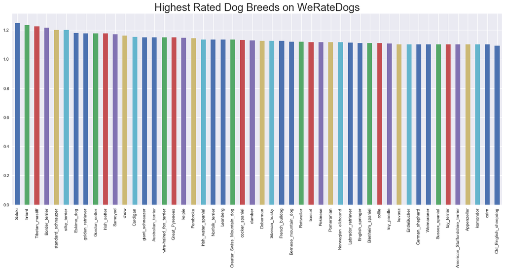

```python
plt.style.use('seaborn')
breed_ax = breed_ratings[1:51].plot(kind='bar', figsize=(20,8))

breed_ax.set_title("Highest Rated Dog Breeds on WeRateDogs", fontsize = 24)
breed_ax.set_xlabel("")
plt.savefig('plots/breed_ratings.png', bbox_inches='tight')
```

The Saluki breed looks to be the top rated.

[figure not shown]

According to the [wikipedia page](https://en.wikipedia.org/wiki/Saluki):

> The Saluki is a dog originally bred in the Fertile Crescent. The saluki is classed as a sighthound and is typically deep-chested and long-legged. Salukis are sighthounds—hunting by sight—and run their quarry down to kill or retrieve it. Historically, salukis were used for hunting by nomadic tribes. Typical quarry included the gazelle, hare, fox, and jackal.

Now lets look at this breed in the twitter archive

```python
df_twitter[df_twitter.p1 == "Saluki"]
```

|  | tweet_id | timestamp | source | text | expanded_urls | name | rating_numerator | rating_denominator | score_rating | dog_label | retweet_count | favorite_count | jpg_url | p1 | p1_conf |
| --- | --- | --- | --- | --- | --- | --- | --- | --- | --- | --- | --- | --- | --- | --- | --- |
| 50 | 881666595344535552 | 2017-07-03 00:11:11 | iphone | This is Gary. He couldn't miss this puppertuni... | https://twitter.com/dog_rates/status/881666595... | Gary | 13.0 | 10.0 | 1.3 | None | 10622.0 | 50181.0 | https://pbs.twimg.com/media/DDxPFwbWAAEbVVR.jpg | Saluki | 0.529012 |
| 70 | 877316821321428993 | 2017-06-21 00:06:44 | iphone | Meet Dante. At first he wasn't a fan of his ne... | https://twitter.com/dog_rates/status/877316821... | Dante | 13.0 | 10.0 | 1.3 | None | 5168.0 | 27194.0 | https://pbs.twimg.com/media/DCza_vtXkAQXGpC.jpg | Saluki | 0.509967 |
| 362 | 817120970343411712 | 2017-01-05 21:29:55 | iphone | Name a more iconic quartet... I'll wait. 13/10... | https://twitter.com/dog_rates/status/817120970... | None | 13.0 | 10.0 | 1.3 | None | 2910.0 | 13099.0 | https://pbs.twimg.com/media/C1b_LSYUsAAJ494.jpg | Saluki | 0.568809 |
| 762 | 750056684286914561 | 2016-07-04 20:00:23 | tweetdeck | This is Jameson. He had a few too many in the ... | https://twitter.com/dog_rates/status/750056684... | Jameson | 11.0 | 10.0 | 1.1 | None | 975.0 | 3347.0 | https://pbs.twimg.com/media/Cmfx2oNW8AAGg4H.jpg | Saluki | 0.484428 |

[figure not shown]

There were only 4 data points for the "Saluki" Breed. But, it looks like the algorithm was not correct in 3 of 4 of these photos. These results made me curious about the confidence level of each breed.

```python
breed_conf = df_twitter.groupby('p1')['p1_conf'].mean()
```

```python
breed_conf = breed_conf.sort_values(ascending = False)
```

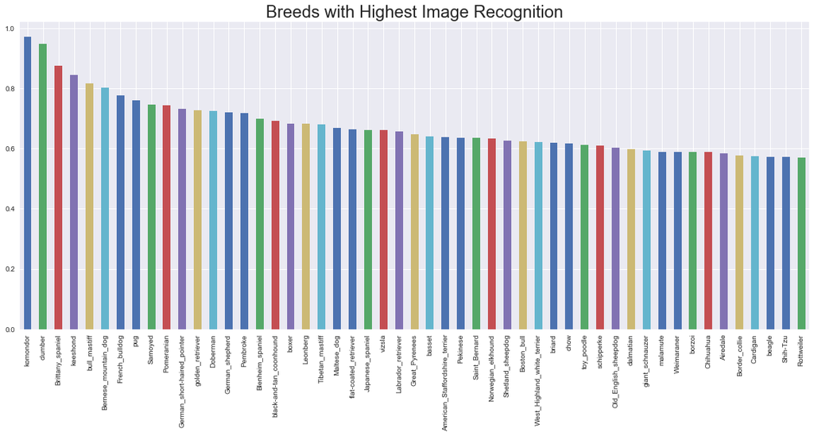

```python
plt.style.use('seaborn')
breed_ax = breed_conf[0:51].plot(kind = "bar",figsize=(20,8))

breed_ax.set_title("Breeds with Highest Image Recognition", fontsize = 24)
breed_ax.set_xlabel("")
plt.savefig('plots/breed_ax.png', bbox_inches='tight')
```

The most recognizable dog to the algorithm for the image predictions is the Komondor breed.

[figure not shown]

Now, let's see which category of dogs is the most popular. And by category, I mean doggo, pupper, puppo, or floofer. Here is a dictionary if you are not familiar with those terms.

[figure not shown]

```python
round(len(df_twitter[df_twitter.dog_label == 'pupper']) / len(df_twitter.dog_label), 2)
```

```
0.11
```

```python
round(len(df_twitter[df_twitter.dog_label == 'doggo']) / len(df_twitter.dog_label), 2)
```

```
0.03
```

```python
round(len(df_twitter[df_twitter.dog_label == 'puppo']) / len(df_twitter.dog_label), 2)
```

```
0.01
```

```python
round(len(df_twitter[df_twitter.dog_label == 'floofer']) / len(df_twitter.dog_label), 3)
```

```
0.005
```

On average, most dogs end up in the pupper category. Which catagory has the highest score rating?

```python
label_rating = df_twitter.groupby('dog_label')['score_rating'].mean()[1:]
```

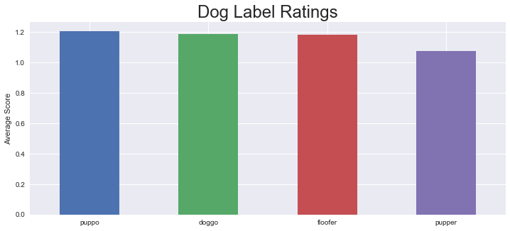

```python
plt.style.use('seaborn')
rating_ax = label_rating.sort_values(ascending = False).plot(kind='bar', figsize=(12,5))

rating_ax.set_title("Dog Label Ratings", fontsize = 24)
plt.xticks(rotation=0)
rating_ax.set_xlabel("")
rating_ax.set_ylabel('Average Score')
plt.savefig('plots/doglabel_rating.png', bbox_inches='tight')
```

Looks like puppo's have the highest average score rating.

Let's now move on to the extracted user data. This data comes from the users that get tagged in certain tweets by WeRateDogs.

```python
user_extract.info()
```

```
<class 'pandas.core.frame.DataFrame'>
RangeIndex: 718 entries, 0 to 717
Data columns (total 7 columns):
account_name     718 non-null object
created_at       718 non-null datetime64[ns]
display_name     718 non-null object
friends_count    718 non-null int64
language         718 non-null object
location         718 non-null object
user_id          718 non-null object
dtypes: datetime64[ns](1), int64(1), object(5)
memory usage: 39.3+ KB
```

```python
user_extract.describe()
```

|  | friends_count |
| --- | --- |
| count | 718.000000 |
| mean | 706.387187 |
| std | 4089.573579 |
| min | 2.000000 |
| 25% | 185.250000 |
| 50% | 302.500000 |
| 75% | 494.750000 |
| max | 76707.000000 |

Average friend count is about 700, while the largest user has over 76,000 friends

```python
user_extract[user_extract['friends_count'] == 76707]
```

|  | account_name | created_at | display_name | friends_count | language | location | user_id |
| --- | --- | --- | --- | --- | --- | --- | --- |
| 620 | Jenna_Marbles | 2009-08-18 14:48:53 | Jenna Marbles | 76707 | en | Horsehead Nebula | 66699013 |
| 621 | Jenna_Marbles | 2009-08-18 14:48:53 | Jenna Marbles | 76707 | en | Horsehead Nebula | 66699013 |

This user is [Jenna Marbles](https://en.wikipedia.org/wiki/Jenna_Marbles), from the wikipedia page:

> Jenna Nicole Mourey (born September 15, 1986, better known by her pseudonym Jenna Marbles, is an American YouTuber, vlogger, comedian, and actress. As of March 2018, her channel has over 2.6 billion video views and 18 million subscribers, making it the 45th most subscribed channel on YouTube and the eighth most popular channel operated by a woman. Marbles is the first social media star to have a wax figure displayed in Madame Tussauds Museum, located in New York City.

It also looks like Jenna has been tagged in WeRateDogs tweets more than once since she has two data points. Also she's located in the Horsehead Nebula, must be nice.

Just for fun, lets look at the most popular locations of the users that get tagged in WeRateDogs.

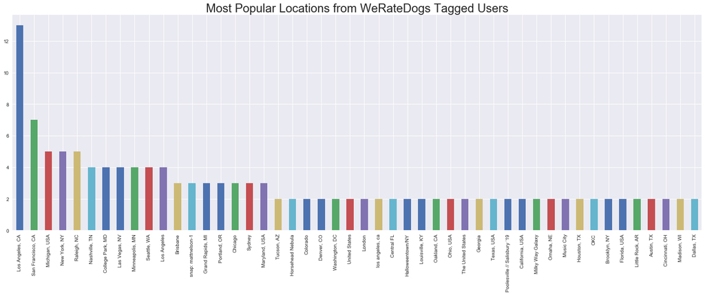

```python
plt.style.use('seaborn')
location_ax = user_extract.location.value_counts()[1:49].plot(kind = "bar", figsize = (25,8))

location_ax.set_title("Most Popular Locations from WeRateDogs Tagged Users", fontsize = 24)
location_ax.set_xlabel("")
plt.savefig('plots/popular_locations.png', bbox_inches='tight')
```

Let's now investigate if there are any frequently tagged users in the WeRateDogs twitter archive.

```python
user_extract.account_name.value_counts().head()
```

```
jengolbeck       4
matt___nelson    3
Joshstram        2
nick_rayy        2
krista_thomas    2
Name: account_name, dtype: int64
```

It looks like the user who gets tagged the most is jengolbeck, [here is her twitter profile](https://twitter.com/jengolbeck):

> Prof @ UMD, Computer Scientist. Social media, research, science, truth, justice, the American way. I also run @theGoldenRatio4

This user is Dr. Jen Golbeck, who happens to also run a fairly popular twitter profile [the golden ratio](https://twitter.com/theGoldenRatio4), it has over 43,000 followers!

[figure not shown]

Awwww